# 重賞レース予測レポート【レース終了】

作成日時: 2025/10/19 16:18:48

☞ [マニュアル(pdf)](https://ryutoro-galois.github.io/keiba-predictor/manual/manual.pdf)

☞ 過去5年の同一レース結果: [2024年](https://ryutoro-galois.github.io/keiba-predictor/report/PredResult_2024y_raceDate_20241013_20241014.html), [2023年](https://ryutoro-galois.github.io/keiba-predictor/report/PredResult_2023y_raceDate_20231014_20231015.html), [2022年](https://ryutoro-galois.github.io/keiba-predictor/report/PredResult_2022y_raceDate_20221015_20221016.html), [2021年](https://ryutoro-galois.github.io/keiba-predictor/report/PredResult_2021y_raceDate_20211016_20211017.html), [2020年](https://ryutoro-galois.github.io/keiba-predictor/report/PredResult_2020y_raceDate_20201017_20201018.html)

☞ 過去4週間の別レース結果: [1週前(10/11-13)](https://ryutoro-galois.github.io/keiba-predictor/report/PredResult_2025y_raceDate_20251011_20251013.html), [2週前(10/5)](https://ryutoro-galois.github.io/keiba-predictor/report/PredResult_2025y_raceDate_20251005_20251005.html), [3週前(9/27-28)](https://ryutoro-galois.github.io/keiba-predictor/report/PredResult_2025y_raceDate_20250927_20250928.html), [4週前(9/20-21)](https://ryutoro-galois.github.io/keiba-predictor/report/PredResult_2025y_raceDate_20250920_20250921.html)

☞ netkeiba: [富士ステークス(GⅡ)](https://race.netkeiba.com/race/result.html?race_id=202505040611&rf=race_submenu), [東京ハイジャンプ(JGⅡ)](https://race.netkeiba.com/race/result.html?race_id=202505040709&rf=race_submenu), [秋華賞(GⅠ)](https://race.netkeiba.com/race/result.html?race_id=202508030711&rf=race_submenu)

☞ レース結果(csv): [10/18-19](https://ryutoro-galois.github.io/keiba-predictor/csv/race_result_20251018_20251019.csv)

## 【レース結果(1)】人気と着順の関係

### 【富士ステークス(2025/10/18(土))】

【富士ステークス(GⅡ)】  
2025/10/18(土), 05_東京, 芝左1600m

[interactive chart not shown]

### 【東京ハイジャンプ(2025/10/19(日))】

【東京ハイジャンプ(J.GⅡ)】  
2025/10/19(日), 05_東京, 障芝3110m

[interactive chart not shown]

### 【秋華賞(2025/10/19(日))】

【秋華賞(GⅠ)】  
2025/10/19(日), 08_京都, 芝右2000m

[interactive chart not shown]

## 【レース結果(2)】コーナー通過順位

### 【富士ステークス(2025/10/18(土))】

【富士ステークス(GⅡ)】  
2025/10/18(土), 05_東京, 芝左1600m

[interactive chart not shown]

### 【東京ハイジャンプ(2025/10/19(日))】

【東京ハイジャンプ(J.GⅡ)】  
2025/10/19(日), 05_東京, 障芝3110m

[interactive chart not shown]

### 【秋華賞(2025/10/19(日))】

【秋華賞(GⅠ)】  
2025/10/19(日), 08_京都, 芝右2000m

[interactive chart not shown]

## 0. 推し馬予測 (AI予測)

### 【富士ステークス(GⅡ) 2025/10/18(土)】

- 本命(◎): 1-3着内確率(勝負強さ)が1位の馬
- 対抗(◯): 1-3着内確率が2-N位(20%程度以上)の中で予測タイムが最も速い馬
- 3番手(▲): 1-3着内確率が2-N位(20%程度以上)のでダークホース確率が最も高い馬
- 穴: ダークホース確率が上位1-M位(40%程度以上)の中で1-3着内確率が最も高い馬

| 推し馬 | 枠番 | 馬番 | 人気 | オッズ | 馬名 | 騎手 | 調教師 | 予測タイム(sec) | 1_順位 | 1-3着内確率(%) | 2_順位 | ﾀﾞｰｸﾎｰｽ確率(%) | 3_順位 |
| --- | --- | --- | --- | --- | --- | --- | --- | --- | --- | --- | --- | --- | --- |
| 本命(◎) | 1 | 1 | 2 | 6.1 | マジックサンズ | 武豊 | 須貝尚介 | 94.7 | 3 | 43.2 | 1 | 0.6 | 14 |
| 対抗(◯) | 6 | 9 | 6 | 17.6 | キープカルム | 坂井瑠星 | 中竹和也 | 97.0 | 4 | 22.9 | 3 | 1.7 | 8 |
| 3番手(▲) | 4 | 5 | 13 | 219.4 | レイベリング | 津村明秀 | 鹿戸雄一 | 97.2 | 5 | 21.9 | 4 | 50.5 | 1 |
| 穴 | 8 | 13 | 10 | 42.4 | ファーヴェント | 佐々木大輔 | 藤原英昭 | 93.7 | 2 | 13.0 | 9 | 40.2 | 2 |

### 【東京ハイジャンプ(J.GⅡ) 2025/10/19(日)】

- 本命(◎): 1-3着内確率(勝負強さ)が1位の馬
- 対抗(◯): 1-3着内確率が2-N位(20%程度以上)の中で予測タイムが最も速い馬
- 3番手(▲): 1-3着内確率が2-N位(20%程度以上)のでダークホース確率が最も高い馬
- 穴: ダークホース確率が上位1-M位(40%程度以上)の中で1-3着内確率が最も高い馬

| 推し馬 | 枠番 | 馬番 | 人気 | オッズ | 馬名 | 騎手 | 調教師 | 予測タイム(sec) | 1_順位 | 1-3着内確率(%) | 2_順位 | ﾀﾞｰｸﾎｰｽ確率(%) | 3_順位 |
| --- | --- | --- | --- | --- | --- | --- | --- | --- | --- | --- | --- | --- | --- |
| 本命(◎) | 5 | 5 | 3 | 4.7 | サイード | 小牧加矢太 | 角田晃一 | 224.3 | 7.0 | 21.9 | 1 | 0.4 | 8 |
| 対抗(◯) | 6 | 6 | 1 | 2.1 | ジューンベロシティ | 高田潤 | 武英智 | 205.8 | 1.0 | 14.7 | 4 | 0.4 | 10 |
| 3番手(▲) | 8 | 9 | 9 | 58.4 | サンマルグレイト | 大江原圭 | 佐藤吉勝 | 222.7 | 4.5 | 10.2 | 6 | 71.0 | 1 |
| 穴 | 1 | 1 | 8 | 50.4 | デシマルサーガ | 上野翔 | 粕谷昌央 | 222.7 | 4.5 | 10.6 | 5 | 56.0 | 2 |

### 【秋華賞(GⅠ) 2025/10/19(日)】

- 本命(◎): 1-3着内確率(勝負強さ)が1位の馬
- 対抗(◯): 1-3着内確率が2-N位(20%程度以上)の中で予測タイムが最も速い馬
- 3番手(▲): 1-3着内確率が2-N位(20%程度以上)のでダークホース確率が最も高い馬
- 穴: ダークホース確率が上位1-M位(40%程度以上)の中で1-3着内確率が最も高い馬

| 推し馬 | 枠番 | 馬番 | 人気 | オッズ | 馬名 | 騎手 | 調教師 | 予測タイム(sec) | 1_順位 | 1-3着内確率(%) | 2_順位 | ﾀﾞｰｸﾎｰｽ確率(%) | 3_順位 |
| --- | --- | --- | --- | --- | --- | --- | --- | --- | --- | --- | --- | --- | --- |
| 本命(◎) | 8 | 17 | 1 | 2.2 | カムニャック | 川田将雅 | 友道康夫 | 116.9 | 1.5 | 28.4 | 1 | 0.7 | 18 |
| 対抗(◯) | 6 | 11 | 2 | 6.3 | エンブロイダリー | Ｃ．ルメール | 森一誠 | 118.3 | 3.0 | 25.3 | 2 | 0.8 | 17 |
| 3番手(▲) | 3 | 5 | 12 | 37.7 | ブラウンラチェット | 池添謙一 | 手塚貴久 | 121.0 | 4.0 | 21.5 | 7 | 42.3 | 7 |
| 穴 | 3 | 6 | 11 | 35.4 | ケリフレッドアスク | 西塚洸二 | 藤原英昭 | 122.2 | 5.0 | 15.9 | 11 | 46.0 | 6 |

## 1. 予測チャート (タイム/勝負強さ)

### 【富士ステークス(GⅡ)】

2025/10/18(土), 05_東京, 芝左1600m

[interactive chart not shown]

### 【東京ハイジャンプ(J.GⅡ)】

2025/10/19(日), 05_東京, 障芝3110m

[interactive chart not shown]

### 【秋華賞(GⅠ)】

2025/10/19(日), 08_京都, 芝右2000m

[interactive chart not shown]

## 2. オッズモニタリング (毎時)

### 【富士ステークス】

[interactive chart not shown]

### 【東京ハイジャンプ】

[interactive chart not shown]

### 【秋華賞】

[interactive chart not shown]

## 3. 出馬表

### 【富士ステークス 2025/10/18(土) 】

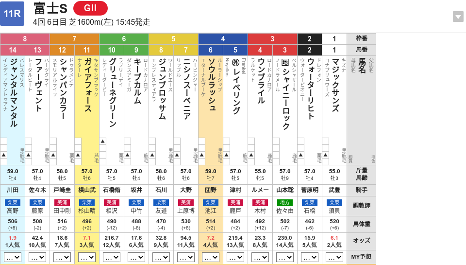

### 【東京ハイジャンプ 2025/10/19(日) 】

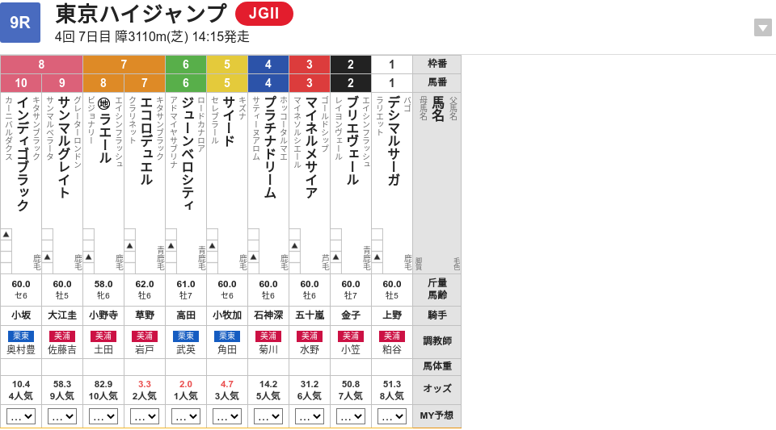

### 【秋華賞 2025/10/19(日) 】

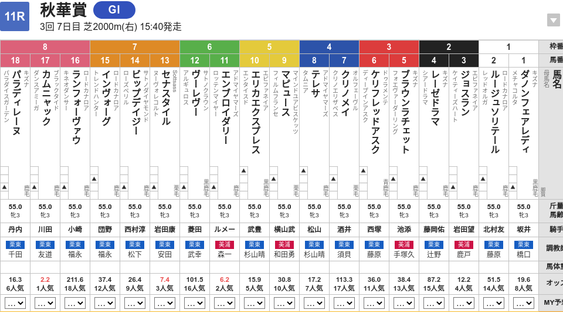

## 4. 単勝予測結果

### 【富士ステークス(GⅡ) 2025/10/18(土)】

| 枠番 | 馬番 | 人気 | オッズ | 馬名 | 騎手 | 調教師 | 予測タイム(sec) | 1_順位 | 1-3着内確率(%) | 2_順位 | ﾀﾞｰｸﾎｰｽ確率(%) | 3_順位 |
| --- | --- | --- | --- | --- | --- | --- | --- | --- | --- | --- | --- | --- |
| 1 | 1 | 2 | 6.1 | マジックサンズ | 武豊 | 須貝尚介 | 94.7 | 3 | 43.2 | 1 | 0.6 | 14 |
| 2 | 2 | 5 | 15.9 | ウォーターリヒト | 菅原明良 | 石橋守 | 99.4 | 11 | 14.3 | 7 | 1.6 | 9 |
| 3 | 3 | 14 | 235.0 | シャイニーロック | 山本聡哉 | 佐々木由則 | 97.7 | 6 | 2.3 | 14 | 16.7 | 5 |
| 3 | 4 | 8 | 23.3 | ウンブライル | Ｃ．ルメール | 木村哲也 | 98.8 | 8 | 11.1 | 10 | 15.9 | 7 |
| 4 | 5 | 13 | 219.4 | レイベリング | 津村明秀 | 鹿戸雄一 | 97.2 | 5 | 21.9 | 4 | 50.5 | 1 |
| 4 | 6 | 4 | 7.2 | ソウルラッシュ | 団野大成 | 池江泰寿 | 99.0 | 9 | 13.7 | 8 | 1.1 | 12 |
| 5 | 7 | 11 | 94.5 | ニシノスーベニア | 大野拓弥 | 上原博之 | 99.3 | 10 | 2.7 | 13 | 29.1 | 4 |
| 5 | 8 | 9 | 32.8 | ジュンブロッサム | 石川裕紀人 | 友道康夫 | 98.8 | 7 | 9.0 | 11 | 36.8 | 3 |
| 6 | 9 | 6 | 17.6 | キープカルム | 坂井瑠星 | 中竹和也 | 97.0 | 4 | 22.9 | 3 | 1.7 | 8 |
| 6 | 10 | 12 | 216.7 | グリューネグリーン | 石橋脩 | 相沢郁 | 100.5 | 12 | 6.3 | 12 | 16.5 | 6 |

[output cut: 4 more lines]

### 【東京ハイジャンプ(J.GⅡ) 2025/10/19(日)】

| 枠番 | 馬番 | 人気 | オッズ | 馬名 | 騎手 | 調教師 | 予測タイム(sec) | 1_順位 | 1-3着内確率(%) | 2_順位 | ﾀﾞｰｸﾎｰｽ確率(%) | 3_順位 |
| --- | --- | --- | --- | --- | --- | --- | --- | --- | --- | --- | --- | --- |
| 1 | 1 | 8 | 50.4 | デシマルサーガ | 上野翔 | 粕谷昌央 | 222.7 | 4.5 | 10.6 | 5 | 56.0 | 2 |
| 2 | 2 | 7 | 48.0 | ブリエヴェール | 金子光希 | 小笠倫弘 | 221.6 | 3.0 | 9.8 | 7 | 46.9 | 3 |
| 3 | 3 | 6 | 30.8 | マイネルメサイア | 五十嵐雄祐 | 水野貴広 | 224.1 | 6.0 | 3.0 | 9 | 9.3 | 5 |
| 4 | 4 | 5 | 13.9 | プラチナドリーム | 石神深一 | 菊川正達 | 224.7 | 10.0 | 7.3 | 8 | 1.0 | 7 |
| 5 | 5 | 3 | 4.7 | サイード | 小牧加矢太 | 角田晃一 | 224.3 | 7.0 | 21.9 | 1 | 0.4 | 8 |
| 6 | 6 | 1 | 2.1 | ジューンベロシティ | 高田潤 | 武英智 | 205.8 | 1.0 | 14.7 | 4 | 0.4 | 10 |
| 7 | 7 | 2 | 3.3 | エコロデュエル | 草野太郎 | 岩戸孝樹 | 224.6 | 9.0 | 19.4 | 2 | 0.4 | 9 |
| 7 | 8 | 10 | 81.2 | ラエール | 小野寺祐太 | 土田稔 | 224.4 | 8.0 | 2.8 | 10 | 24.2 | 4 |
| 8 | 9 | 9 | 58.4 | サンマルグレイト | 大江原圭 | 佐藤吉勝 | 222.7 | 4.5 | 10.2 | 6 | 71.0 | 1 |
| 8 | 10 | 4 | 10.2 | インディゴブラック | 小坂忠士 | 奥村豊 | 213.9 | 2.0 | 17.5 | 3 | 1.1 | 6 |

### 【秋華賞(GⅠ) 2025/10/19(日)】

| 枠番 | 馬番 | 人気 | オッズ | 馬名 | 騎手 | 調教師 | 予測タイム(sec) | 1_順位 | 1-3着内確率(%) | 2_順位 | ﾀﾞｰｸﾎｰｽ確率(%) | 3_順位 |
| --- | --- | --- | --- | --- | --- | --- | --- | --- | --- | --- | --- | --- |
| 1 | 1 | 8 | 19.9 | ダノンフェアレディ | 坂井瑠星 | 橋口慎介 | 123.0 | 12.0 | 14.3 | 13 | 2.3 | 12 |
| 1 | 2 | 14 | 51.5 | ルージュソリテール | 北村友一 | 藤原英昭 | 116.9 | 1.5 | 10.1 | 15 | 54.1 | 4 |
| 2 | 3 | 4 | 12.1 | ジョスラン | 岩田望来 | 鹿戸雄一 | 123.0 | 12.0 | 23.8 | 3 | 1.8 | 15 |
| 2 | 4 | 15 | 87.5 | レーゼドラマ | 藤岡佑介 | 辻野泰之 | 123.0 | 12.0 | 9.6 | 16 | 68.7 | 2 |
| 3 | 5 | 12 | 37.7 | ブラウンラチェット | 池添謙一 | 手塚貴久 | 121.0 | 4.0 | 21.5 | 7 | 42.3 | 7 |
| 3 | 6 | 11 | 35.4 | ケリフレッドアスク | 西塚洸二 | 藤原英昭 | 122.2 | 5.0 | 15.9 | 11 | 46.0 | 6 |
| 4 | 7 | 17 | 110.9 | クリノメイ | 酒井学 | 須貝尚介 | 123.0 | 12.0 | 9.4 | 17 | 73.5 | 1 |
| 4 | 8 | 7 | 17.4 | テレサ | 松山弘平 | 杉山晴紀 | 123.0 | 12.0 | 21.8 | 6 | 2.4 | 11 |
| 5 | 9 | 10 | 30.4 | マピュース | 横山武史 | 和田勇介 | 123.0 | 12.0 | 17.8 | 9 | 38.8 | 8 |
| 5 | 10 | 5 | 16.0 | エリカエクスプレス | 武豊 | 杉山晴紀 | 123.0 | 12.0 | 20.9 | 8 | 2.4 | 10 |

[output cut: 8 more lines]

## 5. 人気と着順の乖離率推移

### 【富士ステークス_1998y_2019y】

[interactive chart not shown]

### 【東京ハイジャンプ_1999y_2019y】

[interactive chart not shown]

### 【秋華賞_1996y_2019y】

[interactive chart not shown]

### 【富士ステークス_1998y_2019y】

| No | 開催年 | 不整合率(%) | 頭数 | 人気別着順(1-3位) | 人気別着順(全体) |
| --- | --- | --- | --- | --- | --- |
| 22 | 2019 | 38.5 | 18頭 | 2-3-4 | 2\|3\|4\|6\|7\|12\|8\|16\|1\|15\|17\|14\|10\|11\|13\|18\|5\|9 |
| 21 | 2018 | 31.2 | 18頭 | 2-3-5 | 2\|3\|5\|1\|4\|7\|12\|6\|14\|10\|9\|18\|17\|8\|13\|11\|16\|15 |
| 20 | 2017 | 24.8 | 15頭 | 1-4-11 | 1\|4\|11\|8\|2\|6\|7\|9\|3\|15\|10\|5\|12\|14\|13 |
| 19 | 2016 | 63.9 | 11頭 | 3-4-2 | 3\|4\|2\|11\|6\|7\|8\|5\|1\|10\|9 |
| 18 | 2015 | 35.4 | 16頭 | 4-1-3 | 4\|1\|3\|12\|2\|5\|9\|10\|11\|15\|16\|8\|7\|13\|6\|14 |
| 17 | 2014 | 41.2 | 16頭 | 2-12-5 | 2\|12\|5\|3\|9\|7\|1\|16\|15\|4\|14\|6\|10\|11\|8\|13 |
| 16 | 2013 | 51.5 | 15頭 | 1-9-14 | 1\|9\|14\|7\|6\|5\|4\|10\|3\|12\|11\|13\|15\|2\|8 |
| 15 | 2012 | 57.1 | 18頭 | 5-3-14 | 5\|3\|14\|10\|9\|2\|11\|1\|6\|8\|7\|15\|12\|4\|13\|18\|17\|16 |
| 14 | 2011 | 18.6 | 17頭 | 1-6-5 | 1\|6\|5\|2\|3\|7\|4\|8\|11\|15\|14\|9\|16\|13\|10\|17\|12 |
| 13 | 2010 | 36.0 | 17頭 | 2-14-13 | 2\|14\|13\|1\|9\|5\|6\|4\|10\|11\|12\|7\|15\|3\|8\|16\|17 |

[output cut: 12 more lines]

### 【東京ハイジャンプ_1999y_2019y】

| No | 開催年 | 不整合率(%) | 頭数 | 人気別着順(1-3位) | 人気別着順(全体) |
| --- | --- | --- | --- | --- | --- |
| 21 | 2019 | 48.8 | 9頭 | 3-2-1 | 3\|2\|1\|6\|4\|5\|7\|9\|8 |
| 20 | 2018 | 66.5 | 10頭 | 4-3-2 | 4\|3\|2\|1\|9\|7\|8\|10\|11\|6 |
| 19 | 2017 | 20.6 | 10頭 | 1-2-6 | 1\|2\|6\|9\|8\|7\|5\|3\|4\|10 |
| 18 | 2016 | 18.5 | 9頭 | 1-3-2 | 1\|3\|2\|4\|6\|7\|9\|5\|10 |
| 17 | 2015 | 47.7 | 10頭 | 3-2-1 | 3\|2\|1\|4\|8\|9\|7\|5\|10\|11 |
| 16 | 2014 | 27.0 | 13頭 | 13-1-5 | 13\|1\|5\|7\|6\|2\|11\|3\|9\|8\|14\|12\|10 |
| 15 | 2013 | 7.8 | 10頭 | 1-3-6 | 1\|3\|6\|4\|5\|10\|7\|8\|9\|11 |
| 14 | 2012 | 49.7 | 11頭 | 2-4-3 | 2\|4\|3\|11\|6\|10\|8\|13\|1\|12\|14 |
| 13 | 2011 | 48.7 | 13頭 | 2-7-9 | 2\|7\|9\|3\|6\|4\|5\|1\|14\|8\|12\|11\|10 |
| 12 | 2010 | 62.8 | 14頭 | 12-3-7 | 12\|3\|7\|2\|6\|8\|5\|4\|1\|13\|9\|10\|14\|11 |

[output cut: 11 more lines]

### 【秋華賞_1996y_2019y】

| No | 開催年 | 不整合率(%) | 頭数 | 人気別着順(1-3位) | 人気別着順(全体) |
| --- | --- | --- | --- | --- | --- |
| 24 | 2019 | 42.2 | 17頭 | 4-2-10 | 4\|2\|10\|13\|6\|14\|11\|1\|3\|9\|12\|17\|7\|15\|5\|8\|16 |
| 23 | 2018 | 32.6 | 17頭 | 1-5-3 | 1\|5\|3\|4\|13\|8\|6\|10\|2\|15\|11\|9\|7\|12\|17\|14\|16 |
| 22 | 2017 | 46.2 | 18頭 | 3-4-5 | 3\|4\|5\|6\|8\|15\|1\|7\|11\|9\|18\|14\|2\|10\|16\|12\|17\|13 |
| 21 | 2016 | 56.5 | 18頭 | 3-4-8 | 3\|4\|8\|2\|5\|10\|9\|7\|6\|1\|14\|15\|18\|12\|13\|11\|17\|16 |
| 20 | 2015 | 29.6 | 18頭 | 1-5-8 | 1\|5\|8\|7\|16\|2\|12\|4\|9\|15\|10\|11\|13\|6\|17\|14\|3\|18 |
| 19 | 2014 | 36.1 | 17頭 | 3-1-4 | 3\|1\|4\|5\|9\|2\|7\|12\|14\|10\|11\|17\|6\|16\|15\|8\|13 |
| 18 | 2013 | 48.5 | 18頭 | 3-2-15 | 3\|2\|15\|1\|12\|8\|9\|11\|16\|7\|5\|4\|6\|10\|14\|17\|13\|18 |
| 17 | 2012 | 18.5 | 18頭 | 1-2-6 | 1\|2\|6\|11\|15\|3\|16\|12\|7\|9\|5\|13\|4\|17\|10\|8\|18\|14 |
| 16 | 2011 | 32.3 | 18頭 | 2-7-1 | 2\|7\|1\|10\|12\|6\|3\|13\|18\|5\|16\|11\|14\|8\|4\|17\|9\|15 |
| 15 | 2010 | 27.6 | 18頭 | 1-6-2 | 1\|6\|2\|4\|15\|10\|13\|12\|7\|17\|8\|14\|18\|11\|9\|5\|16\|3 |

[output cut: 14 more lines]

## 6. 1-3番人気馬の着順分類予測

### 【富士ステークス】

| 分類 | 凡例 | 発生確率(%) | 当該レース | 当該レースランク | 直近1年間 |
| --- | --- | --- | --- | --- | --- |
| 1: 1番人気のみ (1_pop1) | 1 \| * \| * | 17.4 | 1.18 | 1.79 | 0.00 |
| 4: 1,2番人気のみ (4_pop12) | 1 \| 2 \| * | 16.9 | 1.52 | 1.74 | 0.00 |
| 5: 1,3番人気のみ (5_pop13) | 1 \| 3 \| * | 14.0 | 1.89 | 4.38 | 0.00 |
| 8: 1,2,3番人気すべて着外 (8_darkhorse) | * \| * \| * | 13.4 | 0.72 | 2.06 | 0.00 |
| 6: 2,3番人気のみ (6_pop23) | 2 \| 3 \| * | 11.1 | 0.33 | 0.43 | 0.33 |
| 2: 2番人気のみ (2_pop2) | 2 \| * \| * | 10.1 | 0.91 | 1.55 | 0.30 |
| 3: 3番人気のみ (3_pop3) | 3 \| * \| * | 9.7 | 2.62 | 1.49 | 0.00 |
| 7: 1,2,3番人気すべて着内 (7_pop123) | 1 \| 2 \| 3 | 7.3 | 0.00 | 0.23 | 0.22 |

### 【東京ハイジャンプ】

| 分類 | 凡例 | 発生確率(%) | 当該レース | 当該レースランク | 直近1年間 |
| --- | --- | --- | --- | --- | --- |
| 1: 1番人気のみ (1_pop1) | 1 \| * \| * | 17.4 | 1.51 | 1.51 | 0.00 |
| 4: 1,2番人気のみ (4_pop12) | 1 \| 2 \| * | 16.9 | 1.47 | 1.47 | 0.00 |
| 5: 1,3番人気のみ (5_pop13) | 1 \| 3 \| * | 14.0 | 3.68 | 3.68 | 0.00 |
| 8: 1,2,3番人気すべて着外 (8_darkhorse) | * \| * \| * | 13.4 | 1.74 | 1.74 | 0.00 |
| 6: 2,3番人気のみ (6_pop23) | 2 \| 3 \| * | 11.1 | 0.97 | 0.97 | 0.00 |
| 2: 2番人気のみ (2_pop2) | 2 \| * \| * | 10.1 | 1.31 | 1.31 | 0.20 |
| 3: 3番人気のみ (3_pop3) | 3 \| * \| * | 9.7 | 1.26 | 1.26 | 0.00 |
| 7: 1,2,3番人気すべて着内 (7_pop123) | 1 \| 2 \| 3 | 7.3 | 0.19 | 0.19 | 0.15 |

### 【秋華賞】

| 分類 | 凡例 | 発生確率(%) | 当該レース | 当該レースランク | 直近1年間 |
| --- | --- | --- | --- | --- | --- |
| 1: 1番人気のみ (1_pop1) | 1 \| * \| * | 17.4 | 5.12 | 5.12 | 0.00 |
| 4: 1,2番人気のみ (4_pop12) | 1 \| 2 \| * | 16.5 | 0.68 | 0.68 | 0.00 |
| 5: 1,3番人気のみ (5_pop13) | 1 \| 3 \| * | 13.7 | 1.99 | 1.99 | 0.00 |
| 8: 1,2,3番人気すべて着外 (8_darkhorse) | * \| * \| * | 13.0 | 0.94 | 0.94 | 0.00 |
| 7: 1,2,3番人気すべて着内 (7_pop123) | 1 \| 2 \| 3 | 11.4 | 1.65 | 1.65 | 0.23 |
| 2: 2番人気のみ (2_pop2) | 2 \| * \| * | 9.8 | 0.32 | 0.32 | 0.20 |
| 3: 3番人気のみ (3_pop3) | 3 \| * \| * | 9.5 | 0.92 | 0.92 | 0.00 |
| 6: 2,3番人気のみ (6_pop23) | 2 \| 3 \| * | 8.7 | 2.56 | 2.56 | 0.00 |

## 7. 3連複予測結果

### 【富士ステークス(GⅡ) 2025/10/18(土)】

| 分類 | 馬番 | 枠番 | 人気 | 平均予測タイム(sec) | 1-3着内確率(%) | ﾀﾞｰｸﾎｰｽ確率(%) | 馬名 | 騎手 | 調教師 |
| --- | --- | --- | --- | --- | --- | --- | --- | --- | --- |
| 6: 2,3番人気のみ (6_pop23) | 1-11-9 | 1-7-6 | 2-3-6 | 97.47 | 2.55 | 0.00 | マジックサンズ \| ガイアフォース \| キープカルム | 武豊 \| 横山武史 \| 坂井瑠星 | 須貝尚介 \| 杉山晴紀 \| 中竹和也 |
| 6: 2,3番人気のみ (6_pop23) | 1-11-5 | 1-7-4 | 2-3-13 | 97.53 | 2.43 | 0.00 | マジックサンズ \| ガイアフォース \| レイベリング | 武豊 \| 横山武史 \| 津村明秀 | 須貝尚介 \| 杉山晴紀 \| 鹿戸雄一 |
| 2: 2番人気のみ (2_pop2) | 1-9-5 | 1-6-4 | 2-6-13 | 96.30 | 2.17 | 0.01 | マジックサンズ \| キープカルム \| レイベリング | 武豊 \| 坂井瑠星 \| 津村明秀 | 須貝尚介 \| 中竹和也 \| 鹿戸雄一 |
| 6: 2,3番人気のみ (6_pop23) | 1-11-12 | 1-7-7 | 2-3-7 | 98.73 | 2.17 | 0.00 | マジックサンズ \| ガイアフォース \| シャンパンカラー | 武豊 \| 横山武史 \| 戸崎圭太 | 須貝尚介 \| 杉山晴紀 \| 田中剛 |
| 7: 1,2,3番人気すべて着内 (7_pop123) | 14-1-11 | 8-1-7 | 1-2-3 | 95.70 | 2.15 | 0.00 | ジャンタルマンタル \| マジックサンズ \| ガイアフォース | 川田将雅 \| 武豊 \| 横山武史 | 高野友和 \| 須貝尚介 \| 杉山晴紀 |
| 2: 2番人気のみ (2_pop2) | 1-9-12 | 1-6-7 | 2-6-7 | 97.50 | 1.93 | 0.00 | マジックサンズ \| キープカルム \| シャンパンカラー | 武豊 \| 坂井瑠星 \| 戸崎圭太 | 須貝尚介 \| 中竹和也 \| 田中剛 |
| 4: 1,2番人気のみ (4_pop12) | 14-1-9 | 8-1-6 | 1-2-6 | 94.47 | 1.92 | 0.00 | ジャンタルマンタル \| マジックサンズ \| キープカルム | 川田将雅 \| 武豊 \| 坂井瑠星 | 高野友和 \| 須貝尚介 \| 中竹和也 |
| 2: 2番人気のみ (2_pop2) | 1-12-5 | 1-7-4 | 2-7-13 | 97.57 | 1.84 | 0.00 | マジックサンズ \| シャンパンカラー \| レイベリング | 武豊 \| 戸崎圭太 \| 津村明秀 | 須貝尚介 \| 田中剛 \| 鹿戸雄一 |
| 4: 1,2番人気のみ (4_pop12) | 14-1-5 | 8-1-4 | 1-2-13 | 94.53 | 1.83 | 0.00 | ジャンタルマンタル \| マジックサンズ \| レイベリング | 川田将雅 \| 武豊 \| 津村明秀 | 高野友和 \| 須貝尚介 \| 鹿戸雄一 |
| 4: 1,2番人気のみ (4_pop12) | 14-1-12 | 8-1-7 | 1-2-7 | 95.73 | 1.63 | 0.00 | ジャンタルマンタル \| マジックサンズ \| シャンパンカラー | 川田将雅 \| 武豊 \| 戸崎圭太 | 高野友和 \| 須貝尚介 \| 田中剛 |

[output cut: 354 more lines]

### 【東京ハイジャンプ(J.GⅡ) 2025/10/19(日)】

| 分類 | 馬番 | 枠番 | 人気 | 平均予測タイム(sec) | 1-3着内確率(%) | ﾀﾞｰｸﾎｰｽ確率(%) | 馬名 | 騎手 | 調教師 |
| --- | --- | --- | --- | --- | --- | --- | --- | --- | --- |
| 6: 2,3番人気のみ (6_pop23) | 7-5-10 | 7-5-8 | 2-3-4 | 220.93 | 0.74 | 0.00 | エコロデュエル \| サイード \| インディゴブラック | 草野太郎 \| 小牧加矢太 \| 小坂忠士 | 岩戸孝樹 \| 角田晃一 \| 奥村豊 |
| 7: 1,2,3番人気すべて着内 (7_pop123) | 6-7-5 | 6-7-5 | 1-2-3 | 218.23 | 0.62 | 0.00 | ジューンベロシティ \| エコロデュエル \| サイード | 高田潤 \| 草野太郎 \| 小牧加矢太 | 武英智 \| 岩戸孝樹 \| 角田晃一 |
| 5: 1,3番人気のみ (5_pop13) | 6-5-10 | 6-5-8 | 1-3-4 | 214.67 | 0.56 | 0.00 | ジューンベロシティ \| サイード \| インディゴブラック | 高田潤 \| 小牧加矢太 \| 小坂忠士 | 武英智 \| 角田晃一 \| 奥村豊 |
| 4: 1,2番人気のみ (4_pop12) | 6-7-10 | 6-7-8 | 1-2-4 | 214.77 | 0.50 | 0.00 | ジューンベロシティ \| エコロデュエル \| インディゴブラック | 高田潤 \| 草野太郎 \| 小坂忠士 | 武英智 \| 岩戸孝樹 \| 奥村豊 |
| 6: 2,3番人気のみ (6_pop23) | 7-5-1 | 7-5-1 | 2-3-8 | 223.87 | 0.45 | 0.00 | エコロデュエル \| サイード \| デシマルサーガ | 草野太郎 \| 小牧加矢太 \| 上野翔 | 岩戸孝樹 \| 角田晃一 \| 粕谷昌央 |
| 6: 2,3番人気のみ (6_pop23) | 7-5-9 | 7-5-8 | 2-3-9 | 223.87 | 0.43 | 0.00 | エコロデュエル \| サイード \| サンマルグレイト | 草野太郎 \| 小牧加矢太 \| 大江原圭 | 岩戸孝樹 \| 角田晃一 \| 佐藤吉勝 |
| 6: 2,3番人気のみ (6_pop23) | 7-5-2 | 7-5-2 | 2-3-7 | 223.50 | 0.42 | 0.00 | エコロデュエル \| サイード \| ブリエヴェール | 草野太郎 \| 小牧加矢太 \| 金子光希 | 岩戸孝樹 \| 角田晃一 \| 小笠倫弘 |
| 3: 3番人気のみ (3_pop3) | 5-10-1 | 5-8-1 | 3-4-8 | 220.30 | 0.41 | 0.00 | サイード \| インディゴブラック \| デシマルサーガ | 小牧加矢太 \| 小坂忠士 \| 上野翔 | 角田晃一 \| 奥村豊 \| 粕谷昌央 |
| 3: 3番人気のみ (3_pop3) | 5-10-9 | 5-8-8 | 3-4-9 | 220.30 | 0.39 | 0.00 | サイード \| インディゴブラック \| サンマルグレイト | 小牧加矢太 \| 小坂忠士 \| 大江原圭 | 角田晃一 \| 奥村豊 \| 佐藤吉勝 |
| 3: 3番人気のみ (3_pop3) | 5-10-2 | 5-8-2 | 3-4-7 | 219.93 | 0.38 | 0.00 | サイード \| インディゴブラック \| ブリエヴェール | 小牧加矢太 \| 小坂忠士 \| 金子光希 | 角田晃一 \| 奥村豊 \| 小笠倫弘 |

[output cut: 110 more lines]

### 【秋華賞(GⅠ) 2025/10/19(日)】

| 分類 | 馬番 | 枠番 | 人気 | 平均予測タイム(sec) | 1-3着内確率(%) | ﾀﾞｰｸﾎｰｽ確率(%) | 馬名 | 騎手 | 調教師 |
| --- | --- | --- | --- | --- | --- | --- | --- | --- | --- |
| 4: 1,2番人気のみ (4_pop12) | 17-11-3 | 8-6-2 | 1-2-4 | 119.40 | 1.71 | 0.00 | カムニャック \| エンブロイダリー \| ジョスラン | 川田将雅 \| Ｃ．ルメール \| 岩田望来 | 友道康夫 \| 森一誠 \| 鹿戸雄一 |
| 7: 1,2,3番人気すべて着内 (7_pop123) | 17-11-13 | 8-6-7 | 1-2-3 | 119.33 | 1.63 | 0.00 | カムニャック \| エンブロイダリー \| セナスタイル | 川田将雅 \| Ｃ．ルメール \| 岩田康誠 | 友道康夫 \| 森一誠 \| 安田翔伍 |
| 4: 1,2番人気のみ (4_pop12) | 17-11-18 | 8-6-8 | 1-2-6 | 119.40 | 1.57 | 0.00 | カムニャック \| エンブロイダリー \| パラディレーヌ | 川田将雅 \| Ｃ．ルメール \| 丹内祐次 | 友道康夫 \| 森一誠 \| 千田輝彦 |
| 4: 1,2番人気のみ (4_pop12) | 17-11-8 | 8-6-4 | 1-2-7 | 119.40 | 1.57 | 0.00 | カムニャック \| エンブロイダリー \| テレサ | 川田将雅 \| Ｃ．ルメール \| 松山弘平 | 友道康夫 \| 森一誠 \| 杉山晴紀 |
| 4: 1,2番人気のみ (4_pop12) | 17-11-5 | 8-6-3 | 1-2-12 | 118.73 | 1.55 | 0.00 | カムニャック \| エンブロイダリー \| ブラウンラチェット | 川田将雅 \| Ｃ．ルメール \| 池添謙一 | 友道康夫 \| 森一誠 \| 手塚貴久 |
| 5: 1,3番人気のみ (5_pop13) | 17-13-3 | 8-7-2 | 1-3-4 | 120.90 | 1.53 | 0.00 | カムニャック \| セナスタイル \| ジョスラン | 川田将雅 \| 岩田康誠 \| 岩田望来 | 友道康夫 \| 安田翔伍 \| 鹿戸雄一 |
| 4: 1,2番人気のみ (4_pop12) | 17-11-10 | 8-6-5 | 1-2-5 | 119.40 | 1.50 | 0.00 | カムニャック \| エンブロイダリー \| エリカエクスプレス | 川田将雅 \| Ｃ．ルメール \| 武豊 | 友道康夫 \| 森一誠 \| 杉山晴紀 |
| 1: 1番人気のみ (1_pop1) | 17-3-18 | 8-2-8 | 1-4-6 | 120.97 | 1.48 | 0.00 | カムニャック \| ジョスラン \| パラディレーヌ | 川田将雅 \| 岩田望来 \| 丹内祐次 | 友道康夫 \| 鹿戸雄一 \| 千田輝彦 |
| 1: 1番人気のみ (1_pop1) | 17-3-8 | 8-2-4 | 1-4-7 | 120.97 | 1.47 | 0.00 | カムニャック \| ジョスラン \| テレサ | 川田将雅 \| 岩田望来 \| 松山弘平 | 友道康夫 \| 鹿戸雄一 \| 杉山晴紀 |
| 1: 1番人気のみ (1_pop1) | 17-3-5 | 8-2-3 | 1-4-12 | 120.30 | 1.45 | 0.01 | カムニャック \| ジョスラン \| ブラウンラチェット | 川田将雅 \| 岩田望来 \| 池添謙一 | 友道康夫 \| 鹿戸雄一 \| 手塚貴久 |

[output cut: 806 more lines]

## 8. 直近の全レース情報

| No | 日付 | 競馬場 | R | 発走 | レース名 | 距離 | 頭数 | URL(netkeiba) |
| --- | --- | --- | --- | --- | --- | --- | --- | --- |
| 1 | 2025/10/18(土) | 05_東京 | 1R |  | 2歳未勝利 | 1600 | 9頭 | https://race.netkeiba.com/race/shutuba.html?race_id=202505040601&amp;rf=race_list |
| 2 | 2025/10/18(土) | 05_東京 | 2R |  | 2歳未勝利 | 1400 | 7頭 | https://race.netkeiba.com/race/shutuba.html?race_id=202505040602&amp;rf=race_list |
| 3 | 2025/10/18(土) | 05_東京 | 3R |  | 2歳未勝利 | 1800 | 7頭 | https://race.netkeiba.com/race/shutuba.html?race_id=202505040603&amp;rf=race_list |
| 4 | 2025/10/18(土) | 05_東京 | 4R |  | 2歳新馬 | 1400 | 16頭 | https://race.netkeiba.com/race/shutuba.html?race_id=202505040604&amp;rf=race_list |
| 5 | 2025/10/18(土) | 05_東京 | 5R |  | 2歳新馬 | 1600 | 17頭 | https://race.netkeiba.com/race/shutuba.html?race_id=202505040605&amp;rf=race_list |
| 6 | 2025/10/18(土) | 05_東京 | 6R |  | 3歳以上1勝クラス | 1600 | 16頭 | https://race.netkeiba.com/race/shutuba.html?race_id=202505040606&amp;rf=race_list |
| 7 | 2025/10/18(土) | 05_東京 | 7R |  | 3歳以上1勝クラス | 1400 | 17頭 | https://race.netkeiba.com/race/shutuba.html?race_id=202505040607&amp;rf=race_list |
| 8 | 2025/10/18(土) | 05_東京 | 8R |  | 3歳以上2勝クラス | 2000 | 7頭 | https://race.netkeiba.com/race/shutuba.html?race_id=202505040608&amp;rf=race_list |
| 9 | 2025/10/18(土) | 05_東京 | 9R | 14:25 | アイビーS | 1800 | 7頭 | https://race.netkeiba.com/race/shutuba.html?race_id=202505040609&amp;rf=race_list |
| 10 | 2025/10/18(土) | 05_東京 | 10R | 15:00 | 伊勢佐木S | 2100 | 22頭 | https://race.netkeiba.com/race/shutuba.html?race_id=202505040610&amp;rf=race_list |

[output cut: 62 more lines]